# Forschungspraktikum 1+2: Computational Social Science

Session 03: Text-As-Data: Description

Dr. Christian Czymara

## Agenda

- Metrics to describe text-as-data
- Ways to visualize text-as-data
- TF-IDF
- Feature Co-occurrence Matrix
- Tutorial: Describing a scientific paper

## Announcments

- As part of the research training, *free access to DataCamp* is now available for six months
  - Follow [this link](https://www.datacamp.com/groups/shared_links/c935c4206fda4e4d330b7dda94c301e877dfc2ff63108a15682899dae485806c)
  - You need to register with your *@stud.uni-frankfurt.de* address
- New URL for repository
  - The material is available at [https://github.com/*czymaraclass*/CSS_WS24](https://github.com/czymaraclass/CSS_WS24)

# Example Data: US Presidential Inaugural Address Texts

## US Presidential Inaugural Address Texts

- `quanteda` offers a corpus object of [US presidents’ inaugural addresses since 1789](https://quanteda.io/reference/data_corpus_inaugural.html)

```r
quanteda::data_corpus_inaugural
```

```
Corpus consisting of 59 documents and 4 docvars.
1789-Washington :
"Fellow-Citizens of the Senate and of the House of Representa..."

1793-Washington :
"Fellow citizens, I am again called upon by the voice of my c..."

1797-Adams :
"When it was first perceived, in early times, that no middle ..."

1801-Jefferson :
"Friends and Fellow Citizens: Called upon to undertake the du..."

1805-Jefferson :
"Proceeding, fellow citizens, to that qualification which the..."

1809-Madison :
"Unwilling to depart from examples of the most revered author..."

[ reached max_ndoc ... 53 more documents ]
```

## Preparing Inaugural Addresses

```r
toks_inaugural <- tokens(tolower(data_corpus_inaugural),
                     remove_punct = T,
                     remove_numbers = T,
                     remove_symbols = T,
                     remove_separators = T)

toks_inaugural <- tokens_remove(toks_inaugural, stopwords())

toks_inaugural <- tokens_wordstem(toks_inaugural)

toks_inaugural <- tokens_group(toks_inaugural, groups = President)

dfm_inaugural <- dfm(toks_inaugural)
```

# Weighting Terms

## Absolute Term Frequencies

- In the [last tutorial](https://htmlpreview.github.io/?https://github.com/czymaraclass/CSS_WS24/blob/main/tutorials/FoPra_CSS_tutorial_02_solution.html), we mostly described out text data (e.g, the counting the number of terms in a document)
- In many cases, visualizing term frequencies (beyond word clouds) is helpful
- For example, we may want to plot the *total* term frequency
  - Step 1: Identify the most frequently occurring terms within the text (using `quanteda`’s `textstat_frequency()`)
  - Step 2: Plot these terms (e. g., using `ggplot2`)

## Relative Term Frequencies

- However, absolute term frequencies are likely to depend on document length
- All words are more likely to appear in longer texts
- Plot the *relative* term frequency to normalize for text length
  - Step 1: Generate weighted DFM from tokens object (`quanteda`’s `dfm_weight()` function)
  - Step 2: Identify the most frequent terms in this weighted DFM (again `textstat_frequency()`)
  - Step 3: Plot these terms (again `ggplot2`)

## TF-IDF

- Another important way to weight terms is the Term Frequency-Inverse Document Frequency (*TF-IDF*)
- Weights words to emphasize less common, more informative terms
  - Term Frequency (TF): How often a term appears in a document
  - Inverse Document Frequency (IDF): Reduces weight for terms frequent across all documents
- Common words, like “the” or “and,” receive lower weights, minimizing their influence

## Term Frequency (TF)

$$TF(t,d)=\frac{\text{Number of times term } t \text{ appears in document } d}{\text{Total terms in document } d}$$

- Represents the raw count of a word within a document
- A higher TF indicates a term is more frequent within the document
- Example: If “migration” appears 5 times in Document A, which has 100 terms in total:
  - $TF=\frac{5}{100}=0.05$

## Inverse Document Frequency (IDF)

$$IDF(t,N)=\log{\frac{\text{Total number of documents } (N)}{\text{Number of documents containing term } t (n_t)}}$$

- Common terms receive a lower weight; terms in every document have minimal impact ($\log(1)=0$)
- Terms appearing in fewer documents receive a higher weight
- Example: In 10 documents, if “migration” appears in 2:
  - $IDF=\log{\frac{10}{2}}=0.698$

## Calculating TF-IDF

$$TF\text{-}IDF(t,d)=TF(t,d) \times IDF(t)=f_{t,d} \times \log \frac{N}{n_t}$$

- High TF-IDF scores: terms are important to a specific document but rare in others
- Low TF-IDF scores: terms common across documents (less unique information)
- Example:
  - Given $TF=0.05$ and $IDF=0.698$:
  - $TF\text{-}IDF=0.05\times0.698=0.0349$

## DSA Example: DFM

```r
dfm_inaugural
```

```
Document-feature matrix of: 36 documents, 5,381 features (84.91% sparse) and 1 docvar.
           features
docs        first perceiv earli time middl cours america remain unlimit submiss
  Adams        11       1     3    9     1     4       5      3       1       1
  Biden         3       0     0    4     1     0      20      0       0       0
  Buchanan      0       0     0    7     0     0       1      2       0       1
  Bush          6       0     0   24     0     2      38      2       1       0
  Carter        2       0     0    5     0     0       2      0       0       0
  Cleveland     0       0     0    5     0     0       0      0       0       0
[ reached max_ndoc ... 30 more documents, reached max_nfeat ... 5,371 more features ]
```

## DSA Example: Weighted DFM

```r
dfm_weight(dfm_inaugural, scheme = "prop")
```

```
Document-feature matrix of: 36 documents, 5,381 features (84.91% sparse) and 1 docvar.
           features
docs              first      perceiv       earli        time        middl
  Adams     0.004517454 0.0004106776 0.001232033 0.003696099 0.0004106776
  Biden     0.002661934 0            0           0.003549246 0.0008873114
  Buchanan  0           0            0           0.005143277 0
  Bush      0.002057613 0            0           0.008230453 0
  Carter    0.003378378 0            0           0.008445946 0
  Cleveland 0           0            0           0.002780868 0
           features
docs               cours      america       remain      unlimit      submiss
  Adams     0.0016427105 0.0020533881 0.0012320329 0.0004106776 0.0004106776
  Biden     0            0.0177462289 0            0            0
  Buchanan  0            0.0007347539 0.0014695077 0            0.0007347539
  Bush      0.0006858711 0.0130315501 0.0006858711 0.0003429355 0
  Carter    0            0.0033783784 0            0            0
  Cleveland 0            0            0            0            0
[ reached max_ndoc ... 30 more documents, reached max_nfeat ... 5,371 more features ]
```

## DSA Example: TF-IDF

```r
dfm_tfidf(dfm_inaugural)
```

```
Document-feature matrix of: 36 documents, 5,381 features (84.91% sparse) and 1 docvar.
           features
docs            first  perceiv   earli time     middl     cours   america
  Adams     1.0329495 1.079181 1.80618    0 0.6532125 0.4365779 0.9728733
  Biden     0.2817135 0        0          0 0.6532125 0         3.8914933
  Buchanan  0         0        0          0 0         0         0.1945747
  Bush      0.5634270 0        0          0 0         0.2182889 7.3938373
  Carter    0.1878090 0        0          0 0         0         0.3891493
  Cleveland 0         0        0          0 0         0         0
           features
docs           remain   unlimit   submiss
  Adams     0.5837240 0.8573325 0.9542425
  Biden     0         0         0
  Buchanan  0.3891493 0         0.9542425
  Bush      0.3891493 0.8573325 0
  Carter    0         0         0
  Cleveland 0         0         0
[ reached max_ndoc ... 30 more documents, reached max_nfeat ... 5,371 more features ]
```

## Lexical Dispersion

- Examine how the use of specific terms is distributed throughout a document (or set of documents)
- Central terms related to the document’s themes or specific terms of theoretical interest
- Combine `quanteda`’s keywords-in-context function `kwic()` with `quanteda.textplots`’s `textplot_xray()` on the tokens object to generate a lexical dispersion plot for selected terms

## Lexical Dispersion: Example

- When in a speech do US presidents use the term “america” in their inaugural speeches?

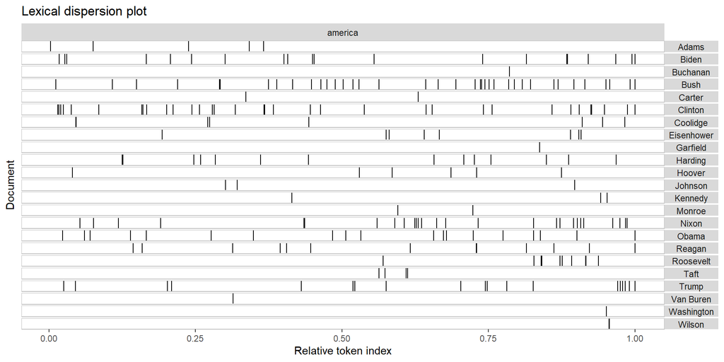

```r
textplot_xray(kwic(toks_inaugural, pattern = "america"))
```

## Relative Token Index

- The relative token index on the x-axis represents the position within the document
- 0: Start of the document
- 1: End of the document
- Calculated by dividing each token’s position by the total number of tokens in the document
- Standardization across different document lengths

# [Tutorial 03](https://htmlpreview.github.io/?https://github.com/czymaraclass/CSS_WS24/blob/main/tutorials/FoPra_CSS_tutorial_03.html): Exercises 1. - 3.

# Comparing texts across document-level characteristics

## `quanteda`’s keyness

- Compare the differential associations of *keywords* in a target and reference group
- Keyness: Score for features that occur differentially across different categories
  - Target category: “Target” document index in the DFM
  - Reference category: All other documents
- Use `quanteda.textstats`’s `textstat_keyness()` function

## `quanteda`’s keyness

- Example: Word usage of Trump vs. Obama

```r
# Subset to Obama and Trump
dfm_obama_trump <- dfm_subset(dfm_inaugural,
                              President %in% c("Obama", "Trump"))

# Calculate keyness and determine Trump as target group
pres_keyness <- textstat_keyness(dfm_obama_trump, target = "Trump")

pres_keyness
```

```
                 feature          chi2            p n_target n_reference
1                america  1.361672e+01 0.0002241799       19          19
2                countri  1.224680e+01 0.0004660561       12           9
3                  dream  1.113180e+01 0.0008486028        6           1
4               american  1.072025e+01 0.0010596912       15          15
5                protect  8.937097e+00 0.0027943646        7           3
6                everyon  8.623734e+00 0.0033181089        4           0
7                  first  8.623734e+00 0.0033181089        4           0
8                   back  8.527087e+00 0.0034989935        6           2
9                    one  6.047579e+00 0.0139253800        9           8
10               foreign  5.639350e+00 0.0175617144        3           0
11               million  5.639350e+00 0.0175617144        3           0
12                 obama  5.639350e+00 0.0175617144        3           0
13              transfer  5.639350e+00 0.0175617144        3           0
14                 never  5.073256e+00 0.0242976971        6           4
```

[output cut: 5367 more lines]

## Plot keyness using `quanteda.textplots`

```r
library(quanteda.textplots)

textplot_keyness(pres_keyness)
```

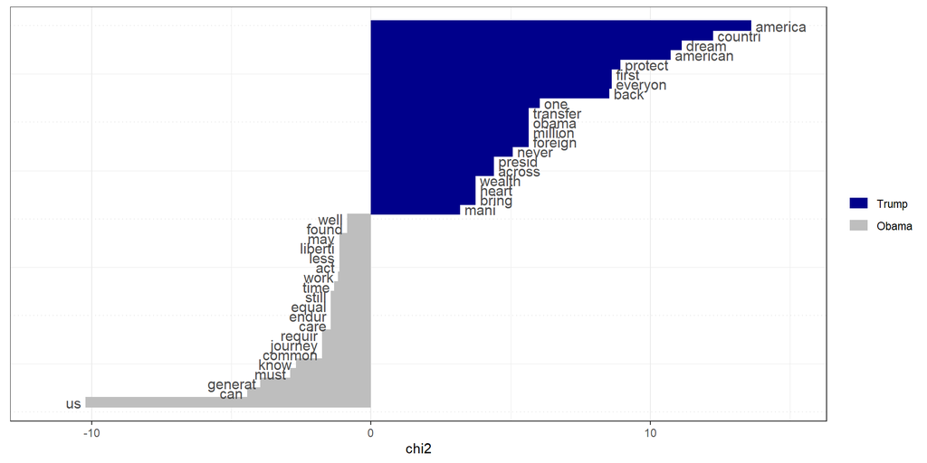

# Word Co-occurrence

## $n$-grams

- $n$-grams: Sequences of ‘n’ adjacent words in text
- Distinguishes between phrases like “not-bad” vs. “not-good”
- Adds nuance to simple word counts
- Bigram (2-gram): Pair of consecutive words
  - For example, “the movie” or “not bad”
- However, more word combinations than unique words
- For less frequent pairs, difficult to find enough examples to generalize

## Higher-order $n$-grams

- Trigrams (3-grams) and beyond add more context but:
  - Increase DTM size
  - Worsen data scarcity
- Select important features only (based on theoretical or empirical reasoning)

## Trigrams Example

```r
text = "This is a test"
tokens(text) %>%
  tokens_tolower() %>%
  tokens_ngrams(1:3)
```

```
Tokens consisting of 1 document.
text1 :
[1] "this"      "is"        "a"         "test"      "this_is"   "is_a"
[7] "a_test"    "this_is_a" "is_a_test"
```

## Collocations

- Special case of $n$-grams
- Word pairs that occur more often than expected by chance
- Example: “artificial intelligence” usually appears more frequently together than “artificial” or “intelligence” alone
- Specific meanings, for example:
  - Place names: New York, Los Angeles
  - Common phrases: social media, climate change
  - Unique meanings: strong coffee, fast food
  - Disambiguation: Context clarifies terms, e.g., “take off the ground” vs. “take off work”

## Collocations: Lambda

- Collocations are based on the *lambda* metric, which measures the association strength between two words
- Derived from log-linear models estimating interaction effects
- Compares the probability of words appearing together vs. their individual probabilities
- Higher lambda scores indicate stronger collocations

# [Tutorial 03](https://htmlpreview.github.io/?https://github.com/czymaraclass/CSS_WS24/blob/main/tutorials/FoPra_CSS_tutorial_03.html): Exercise 4.

## Feature Co-occurrence Matrix

- A Feature Co-occurrence Matrix (FCM) can be seen as a special case of a DFM
- FCM represents the frequency with which features appear together within a given context
- The context is defined by the unit of analysis (e.g., sentence, document)
- This, in turn, corresponds to the rows of the DFM

## Create a FCM

- Use `quanteda`’s `cfm()` function on a `dfm` object

```r
fcm_inaugural <- fcm(dfm_inaugural)

fcm_inaugural
```

```
Feature co-occurrence matrix of: 5,381 by 5,381 features.
         features
features  first perceiv earli time middl cours america remain unlimit submiss
  first     217      16   110  954    44   238     856    217      36      13
  perceiv     0       1     4   26     1     6       6     16       3       1
  earli       0       0    23  234     7    78      52     72       9       7
  time        0       0     0 1517   128   558    3120    624      64      28
  middl       0       0     0    0     3    18     179     22       3       1
  cours       0       0     0    0     0    66     399    123      13       7
  america     0       0     0    0     0     0    2471    432      53       6
  remain      0       0     0    0     0     0       0     66      16      10
  unlimit     0       0     0    0     0     0       0      0       0       1
  submiss     0       0     0    0     0     0       0      0       0       0
[ reached max_feat ... 5,371 more features, reached max_nfeat ... 5,371 more features ]
```

## Reduced FCMs

- Number of possible word combinations increase quickly in texts with more terms
- Examine the combination of a selection of words
- Selection might be based on theoretical interest or frequencies

## Step 1: Identify features

- Choose features (e.g., words, items) to analyze
- For example, use the 20 most prevalent terms of the DFM

```r
top_terms <- names(topfeatures(dfm_inaugural, 20))

top_terms
```

```
 [1] "nation"    "govern"    "peopl"     "us"        "can"       "state"
 [7] "great"     "must"      "power"     "upon"      "countri"   "world"
[13] "may"       "shall"     "everi"     "constitut" "peac"      "one"
[19] "right"     "time"
```

## Step 2: Subset the FCM

- Reduce the rows and columns in the FCM to those terms

```r
fcm_inaugural_top_terms <- fcm_select(fcm_inaugural, pattern = top_terms)

fcm_inaugural_top_terms
```

```
Feature co-occurrence matrix of: 20 by 20 features.
         features
features  time power must govern countri peopl nation  one  may state
  time    1517  3702 3869   6031    3013  6080   6397 2814 2999  4064
  power      0  4850 4281  11753    5794 10877   8354 4612 6948 10663
  must       0     0 3066   7871    3936  8122   8470 3705 3995  4694
  govern     0     0    0   9420    8775 16220  14213 6866 9330 14345
  countri    0     0    0      0    2563  7807   7545 3430 4754  6993
  peopl      0     0    0      0       0  8282  14577 6440 8561 11684
  nation     0     0    0      0       0     0   8264 5837 7204  9539
  one        0     0    0      0       0     0      0 1666 3630  5257
  may        0     0    0      0       0     0      0    0 2778  8142
  state      0     0    0      0       0     0      0    0    0  6634
[ reached max_feat ... 10 more features, reached max_nfeat ... 10 more features ]
```

# [Tutorial 03](https://htmlpreview.github.io/?https://github.com/czymaraclass/CSS_WS24/blob/main/tutorials/FoPra_CSS_tutorial_03.html): Exercise 5.